# Q1a

```r
library(spdep); library(sf); library(leaflet)
```

```r
# Load the data
amsterdam <- read.csv("AmsterdamRent.csv")
amsterdam
```

```
##                       Street Size Rent  Y_coord  X_coord
## 1                     Amstel    8  740 52.20667 4.734720
## 2         August Allebeplein   10  710 52.36335 4.836655
## 3           Bos en Lommerweg    8  590 52.38080 4.854600
## 4           Bos en Lommerweg   12  690 52.38080 4.854600
## 5            Coornhertstraat   18  620 51.90528 4.313682
## 6            Coornhertstraat   20  660 51.90528 4.313682
## 7            Coornhertstraat   20  660 51.90528 4.313682
## 8            Coornhertstraat   22  670 51.90528 4.313682
## 9               De Boelelaan   10  630 52.33428 4.868861
## 10      Derde Schinkelstraat   22  820 52.35306 4.855753
## 11      Emmy Andriessestraat   10  735 52.34690 5.010640
## 12               Geerdinkhof   12  490 52.32597 4.982374
## 13              Gouden Leeuw   13  635 52.32425 4.973837
## 14             Granidastraat   35 1140 52.37896 4.848978
```

[output cut: 24 more lines]

```r
# Convert to spatial data frame
amsterdam_sf <- st_as_sf(amsterdam, coords = c("X_coord", "Y_coord"), crs = 4326)
amsterdam_sf
```

```
## Simple feature collection with 38 features and 3 fields
## Geometry type: POINT
## Dimension:     XY
## Bounding box:  xmin: 4.313682 ymin: 51.90528 xmax: 5.01064 ymax: 52.39486
## Geodetic CRS:  WGS 84
## First 10 features:
##                  Street Size Rent                  geometry
## 1                Amstel    8  740  POINT (4.73472 52.20667)
## 2    August Allebeplein   10  710 POINT (4.836655 52.36335)
## 3      Bos en Lommerweg    8  590    POINT (4.8546 52.3808)
## 4      Bos en Lommerweg   12  690    POINT (4.8546 52.3808)
## 5       Coornhertstraat   18  620 POINT (4.313682 51.90528)
## 6       Coornhertstraat   20  660 POINT (4.313682 51.90528)
## 7       Coornhertstraat   20  660 POINT (4.313682 51.90528)
## 8       Coornhertstraat   22  670 POINT (4.313682 51.90528)
## 9          De Boelelaan   10  630 POINT (4.868861 52.33428)
## 10 Derde Schinkelstraat   22  820 POINT (4.855753 52.35306)
```

```r
# i.
# Transforming CRS
amsterdam_sf <- st_transform(amsterdam_sf, crs = 7080)
amsterdam_sf
```

```
## Simple feature collection with 38 features and 3 fields
## Geometry type: POINT
## Dimension:     XY
## Bounding box:  xmin: -3753156 ymin: 18349470 xmax: -3670418 ymax: 18378080
## Projected CRS: RGTAAF07 / UTM zone 43S
## First 10 features:
##                  Street Size Rent                  geometry
## 1                Amstel    8  740 POINT (-3701143 18362622)
## 2    August Allebeplein   10  710 POINT (-3678232 18363693)
## 3      Bos en Lommerweg    8  590 POINT (-3675457 18363317)
## 4      Bos en Lommerweg   12  690 POINT (-3675457 18363317)
## 5       Coornhertstraat   18  620 POINT (-3753156 18378080)
## 6       Coornhertstraat   20  660 POINT (-3753156 18378080)
## 7       Coornhertstraat   20  660 POINT (-3753156 18378080)
## 8       Coornhertstraat   22  670 POINT (-3753156 18378080)
## 9          De Boelelaan   10  630 POINT (-3680715 18359618)
## 10 Derde Schinkelstraat   22  820 POINT (-3678846 18361668)
```

```r
# Check if geometries are valid after CRS transformation
validity_check <- st_is_valid(amsterdam_sf)
validity_check
```

```
##  [1] TRUE TRUE TRUE TRUE TRUE TRUE TRUE TRUE TRUE TRUE TRUE TRUE TRUE TRUE
## [15] TRUE TRUE TRUE TRUE TRUE TRUE TRUE TRUE TRUE TRUE TRUE TRUE TRUE TRUE
## [29] TRUE TRUE TRUE TRUE TRUE TRUE TRUE TRUE TRUE TRUE
```

```r
# If any geometries are invalid, print them
if (any(!validity_check)) {
  cat("Invalid geometries found:\n")
  print(amsterdam_sf[!validity_check, ])
} else {
  cat("All geometries are valid.\n")
}
```

```
## All geometries are valid.
```

```r
# Create neighbourhood connectivity object with 4 nearest neighbours
coords <- st_coordinates(amsterdam_sf)
nn4 <- knearneigh(coords, k = 4)
nb_4nn <- knn2nb(nn4)
# Display summary of the connectivity object
cat("Summary of the neighbourhood connectivity object (4 nearest neighbours):\n")
```

```
## Summary of the neighbourhood connectivity object (4 nearest neighbours):
```

```r
summary(nb_4nn)
```

```
## Neighbour list object:
## Number of regions: 38
## Number of nonzero links: 152
## Percentage nonzero weights: 10.52632
## Average number of links: 4
## 3 disjoint connected subgraphs
## Non-symmetric neighbours list
## Link number distribution:
##
##  4
## 38
## 38 least connected regions:
## 1 2 3 4 5 6 7 8 9 10 11 12 13 14 15 16 17 18 19 20 21 22 23 24 25 26 27 28 29 30 31 32 33 34 35 36 37 38 with 4 links
## 38 most connected regions:
## 1 2 3 4 5 6 7 8 9 10 11 12 13 14 15 16 17 18 19 20 21 22 23 24 25 26 27 28 29 30 31 32 33 34 35 36 37 38 with 4 links
```

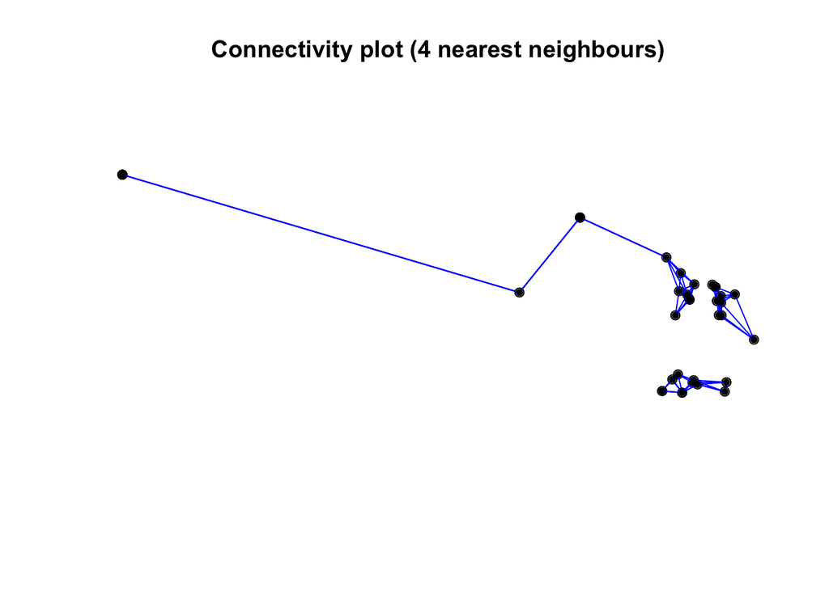

```r
# ii.
plot(st_geometry(amsterdam_sf), main = "Connectivity plot (4 nearest neighbours)")
plot(nb_4nn, coords, add = TRUE, col = "blue", pch = 20)
```

3. A distance-based neighbourhood object may not be suitable in this case because the rental transactions in Amsterdam are spatially dispersed, leading to disjoint clusters in certain areas. The plot shows that some areas of the city are isolated from others, resulting in three disconnected subgraphs. This disconnection suggests that a purely distance-based approach may fail to capture the true spatial dependencies across all neighbourhoods, as areas further apart are not connected despite possibly sharing similar characteristics. Instead, a neighbourhood definition based on spatial contiguity or a method that considers the city’s structure may be more suitable for capturing relevant spatial relationships.

```r
weights_list <- nb2listw(nb_4nn, style = "W")
cat("Weights list object created with row-normalised weights style.\n")
```

```
## Weights list object created with row-normalised weights style.
```

```r
weights_list
```

```
## Characteristics of weights list object:
## Neighbour list object:
## Number of regions: 38
## Number of nonzero links: 152
## Percentage nonzero weights: 10.52632
## Average number of links: 4
## 3 disjoint connected subgraphs
## Non-symmetric neighbours list
##
## Weights style: W
## Weights constants summary:
##    n   nn S0    S1     S2
## W 38 1444 38 15.75 163.75
```

```r
# i.
moran_test_result <- moran.test(amsterdam_sf$Rent, weights_list)
cat("D-i Moran's test result on 'rent':\n")
```

```
## D-i Moran's test result on 'rent':
```

```r
moran_test_result
```

```
##
##  Moran I test under randomisation
##
## data:  amsterdam_sf$Rent
## weights: weights_list
##
## Moran I statistic standard deviate = 3.5864, p-value = 0.0001677
## alternative hypothesis: greater
## sample estimates:
## Moran I statistic       Expectation          Variance
##        0.31726842       -0.02702703        0.00921629
```

Comment: Based on the results of Moran’s test shown above,

- Moran’s I statistic: 0.31726842, which indicates a positive spatial autocorrelation. This means that similar rental prices (either high or low) tend to be geographically clustered in Amsterdam.
- $p$-value: 0.0001677, which is much smaller than the 5% significance level. This low $p$-value suggests that the observed spatial autocorrelation in rental prices is statistically significant.

Since the $p$-value is well below the 5% significance threshold, we reject the null hypothesis of no spatial autocorrelation. The positive Moran’s I statistic confirms that rental prices in Amsterdam exhibit significant spatial clustering. In practical terms, areas with higher rents are likely to be near other high-rent areas, while lower-rent areas are similarly clustered. This spatial dependency is essential for understanding the geographic structure of rental prices in the city.

```r
# ii.
n <- nrow(amsterdam_sf)  # Number of observations
null_moran_I <- -1 / (n - 1)
cat("Null Moran's I statistic (expected under the null hypothesis):", null_moran_I, "\n")
```

```
## Null Moran's I statistic (expected under the null hypothesis): -0.02702703
```

```r
# iii.
local_morans <- localmoran(amsterdam_sf$Rent, weights_list)
colnames(local_morans) <- c("Local_I", "Expectation", "Variance", "Z_score", "P_value")

# Calculate the global Moran's I as the sum of local Moran's I statistics divided by sum of weights
global_moran_I_from_locals <- sum(local_morans[, "Local_I"]) / sum(unlist(weights_list$weights))
cat("Global Moran's I calculated as the sum of local Moran's I statistics:", global_moran_I_from_locals, "\n")
```

```
## Global Moran's I calculated as the sum of local Moran's I statistics: 0.3172684
```

```r
# Display the local Moran's I values for each location
head(local_morans)
```

```
##       Local_I   Expectation     Variance    Z_score    P_value
## 1  0.24178022 -1.118792e-03 0.0097319137  2.4622187 0.01380804
## 2 -0.01473162 -8.392415e-05 0.0007307782 -0.5418467 0.58792412
## 3 -0.63602058 -7.741946e-03 0.0668974924 -2.4291111 0.01513589
## 4 -0.04555516 -4.942856e-05 0.0004304191 -2.1934125 0.02827768
## 5  0.03088148 -4.057817e-03 0.0351934309  0.1862444 0.85225307
## 6  0.02456361 -9.808096e-04 0.0085328400  0.2765345 0.78213760
```

```r
# iv.
# Calculate local Moran's I statistics for burglaries
local_morans_rent <- localmoran(amsterdam_sf$Rent, weights_list)
colnames(local_morans_rent) <- c("Local_I", "Expectation", "Variance", "Z_score", "P_value")

# Count the number of spatial outliers (p-value < 0.05)
spatial_outliers_count <- sum(local_morans_rent[, "P_value"] < 0.05)
cat("Number of spatial outliers for rent:", spatial_outliers_count, "\n")
```

```
## Number of spatial outliers for rent: 11
```

```r
# Geary's C test on the "Rent" variable
geary_test_result <- geary.test(amsterdam_sf$Rent, weights_list)
cat("Geary's C test result on 'Rent':\n")
```

```
## Geary's C test result on 'Rent':
```

```r
geary_test_result
```

```
##
##  Geary C test under randomisation
##
## data:  amsterdam_sf$Rent
## weights: weights_list
##
## Geary C statistic standard deviate = 2.1738, p-value = 0.01486
## alternative hypothesis: Expectation greater than statistic
## sample estimates:
## Geary C statistic       Expectation          Variance
##        0.74939138        1.00000000        0.01329062
```

```r
# Comparison with Moran's I test results
cat("\nComparison of Moran's I and Geary's C:\n")
```

```
##
## Comparison of Moran's I and Geary's C:
```

```r
cat("Moran's I statistic:", moran_test_result$estimate["Moran I statistic"],
    "with p-value:", moran_test_result$p.value, "\n")
```

```
## Moran's I statistic: 0.3172684 with p-value: 0.0001676665
```

```r
cat("Geary's C statistic:", geary_test_result$estimate["Geary C statistic"],
    "with p-value:", geary_test_result$p.value, "\n")
```

```
## Geary's C statistic: 0.7493914 with p-value: 0.01485938
```

Comment: Based on the results of the two tests shown above,

- Moran’s I: The Moran’s I statistic is 0.3172684 with a $p$-value of 0.0001677. This result indicates significant global spatial autocorrelation in rental prices in Amsterdam, suggesting that similar values (high or low rents) tend to be spatially clustered.
- Geary’s C: The Geary’s C statistic is 0.7493914 with a $p$-value of 0.0148594. Since this $p$-value is below the 5% significance level, it suggests significant local spatial autocorrelation in the “Rent” variable. Geary’s C statistic being below 1 further indicates positive local spatial correlation, with nearby rental prices showing more similarity than would be expected by random chance.

##### Interpretation

Both tests show significant spatial autocorrelation in the “Rent” variable, but they highlight different aspects:

- Moran’s I emphasises global spatial autocorrelation, showing that rental prices are generally clustered across the entire area.
- Geary’s C is more sensitive to local spatial differences, supporting the presence of local clusters or pockets where rents are similar.

Together, these results suggest that rental prices in Amsterdam are not only globally clustered but also exhibit localised clusters, potentially due to neighbourhood effects or localised market dynamics.